# 2-ой этап индивидуального проекта

Операционные системы

Верниковская Е. А., НПИбд-01-23

Российский университет дружбы народов, Москва, Россия

14 марта 2024

# Вводная часть

## Цель работы

Добавить на сайт данные о себе.

## Задание

1. Разместить фотографию владельца сайта.
2. Разместить краткое описание владельца сайта (Biography).
3. Добавить информацию об интересах (Interests).
4. Добавить информацию от образовании (Education).
5. Сделать пост по прошедшей неделе.
6. Добавить пост на тему по выбору:
- Управление версиями. Git.
- Непрерывная интеграция и непрерывное развертывание (CI/CD).

# Выполнение 2-ого этапа индивидуального проекта

## Размещение фотографии владельца на сайте

Далее запускаем исполняемый файл hugo, с помощью команды *~/bin/hugo server* и переходим на наш локальный сайт (рис. 2)

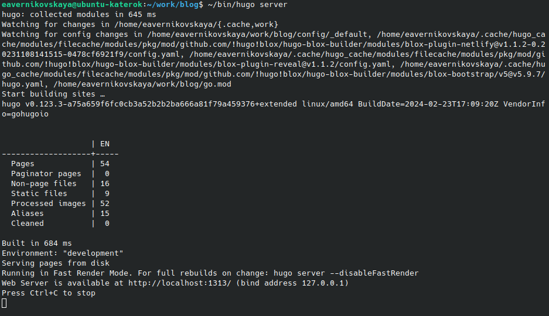

Запуск исполняемого файла

## Размещение фотографии владельца на сайте

Потом переходим в каталог ~/work/blog/content/authors/admin и меняем фотографию владельца сайта на свою (рис. 3), (рис. 4)

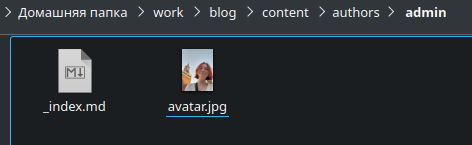

Изменение аватара

## Размещение фотографии владельца на сайте

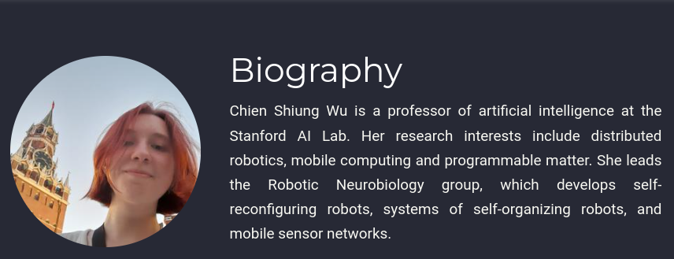

Изменённый аватар на локальном сайте

## Размещение информации о владельце на сайте

Далее в том же каталоге открываем файл _index.md и заполняем информацию о себе (имя владельца сайта, Interests и Education) (рис. 5)

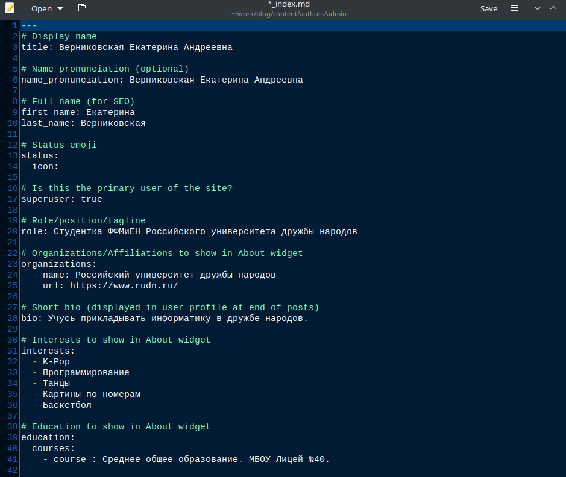

Редактирование файла _index.md

## Размещение информации о владельце на сайте

В конце файла пишем краткое описание о себе, т.е о владельце сайта (Biography) (рис. 6)

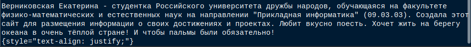

Описание владельца сайта

## Размещение постов на сайте

Переходим в каталог ~/work/blog/content/post и создаём две папки (я назвала их *post_1* и *post_2*), где будут хранится материалы постов (рис. 7), (рис. 8), (рис. 9)

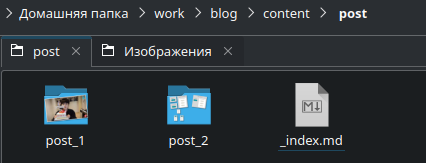

Папки с материалама постов

## Размещение постов на сайте

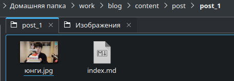

Материалы для поста о прошедшей неделе

## Размещение постов на сайте

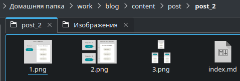

Материалы для поста по выбранной теме

## Размещение постов на сайте

Редактируем в папке post_1 файл index.md. Пишем там пост о нашей прошедшей неделе, по желанию вставляем картинки (рис. 10)

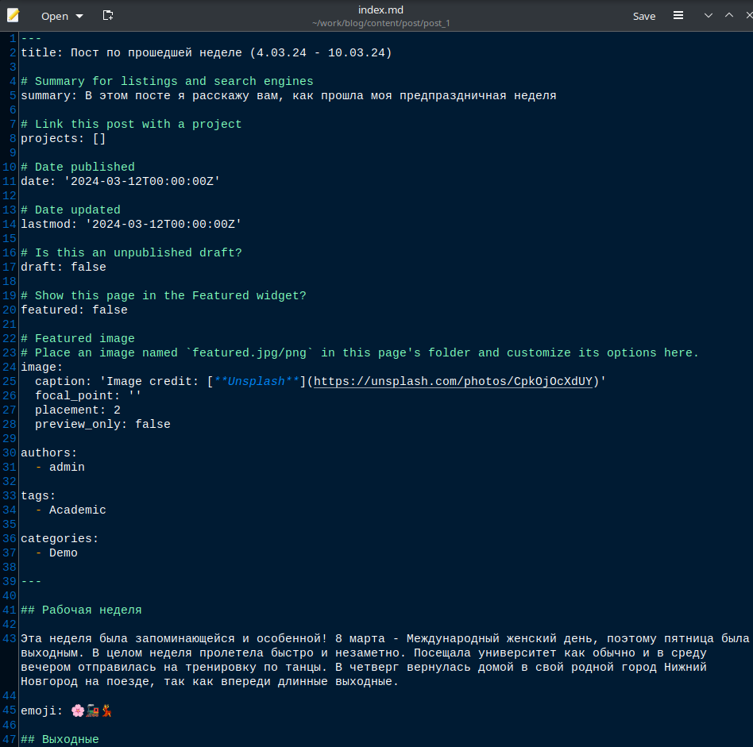

Файл поста по прошедшей неделе

## Размещение постов на сайте

Далее редактируем другой файл index.md в папке post_2. Я выбрала тему “Управление версиями. Git.” (рис. 11)

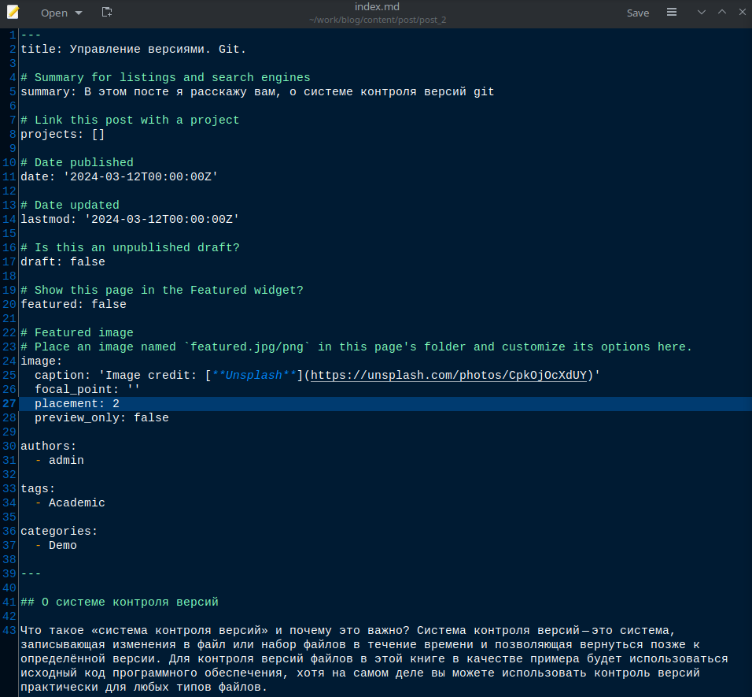

Файл поста по выборанной теме

## Сборка сайта

Собираем наш сайт выполнив в каталоге ~/work/blog команду *~/bin/hugo* (рис. 12)

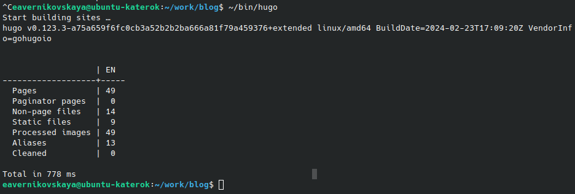

Сборка сайта

## Сборка сайта

Далее сохраняем изменения и отправляем их на git (рис. 13)

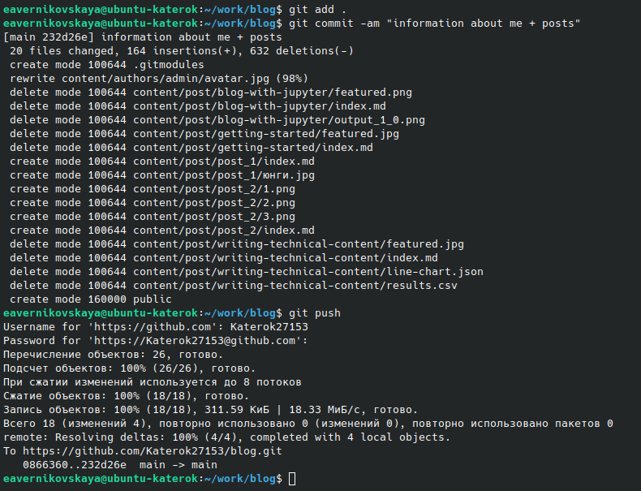

Сохранение и отправка изменений на git

## Сборка сайта

Далее переходим в каталог ~/work/blog/public и также сохраняем изменения и выкладываем их на git (рис. 14), (рис. 15)

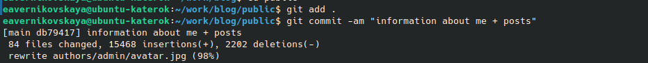

Сохранение и коммит изменений

## Сборка сайта

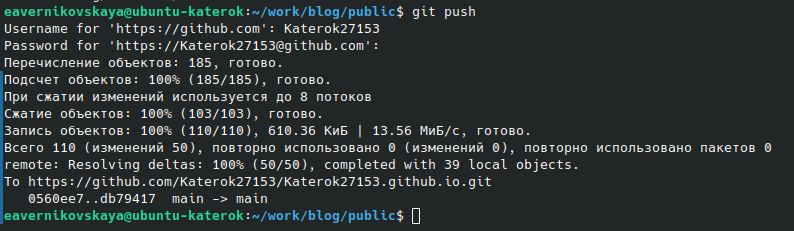

Отправка изменений на git

## Сборка сайта

Далее переходим на наш сайт (не на локальный!) по ссылке katerok27153.github.io и видим что всё получилось (рис. 16), (рис. 17), (рис. 18), (рис. 19)

## Сборка сайта

[figure not shown]

Страница сайта с изменённой информацией о владельце

## Сборка сайта

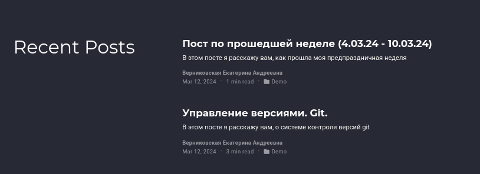

Посты на сайте

## Сборка сайта

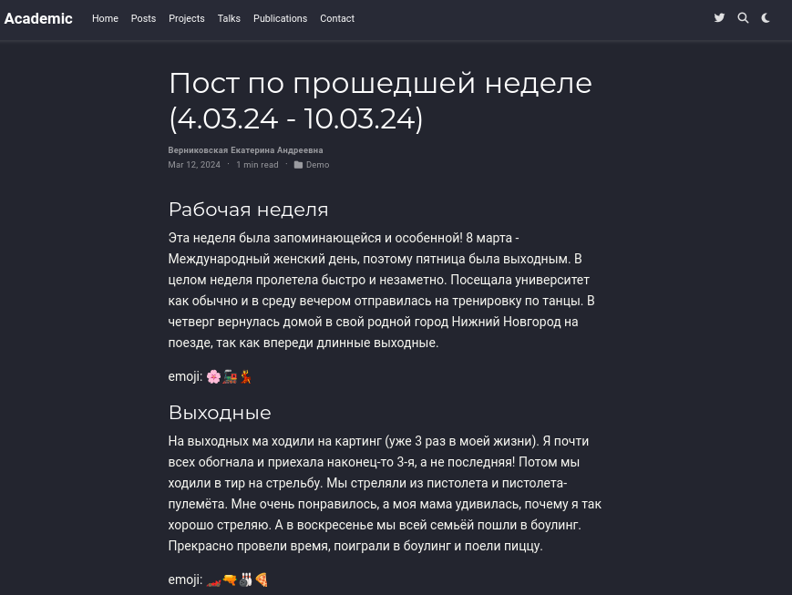

Пост по прошедшей неделе

## Сборка сайта

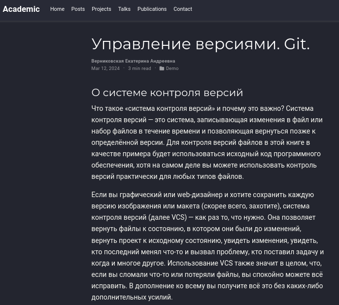

Пост на тему “Управление версиями. Git.”

# Подведение итогов

## Выводы

В ходе выполнения 2-ого этапа индивидуального проекта мы научились размещать на сайте данные о себе и выкладывать посты.

## Список литературы

1. Мой сайт [Электронный ресурс] URL: https://katerok27153.github.io/
2. Этапы реализации проекта [Электронный ресурс] URL: https://esystem.rudn.ru/mod/page/view.php?id=1098920